# Collinearity

- Collinearity refers to the situation in which two or more predictor variables are **closely related** to one another.

We illustrate the concept of collinearity using the `Credit` data set in `ISLR` package.

```r
library(ISLR)
head(Credit)
dim(Credit)
```

| ID | Income | Limit | Rating | Cards | Age | Education | Gender | Student | Married | Ethnicity | Balance |
| --- | --- | --- | --- | --- | --- | --- | --- | --- | --- | --- | --- |
| 1 | 14.891 | 3606 | 283 | 2 | 34 | 11 | Male | No | Yes | Caucasian | 333 |
| 2 | 106.025 | 6645 | 483 | 3 | 82 | 15 | Female | Yes | Yes | Asian | 903 |
| 3 | 104.593 | 7075 | 514 | 4 | 71 | 11 | Male | No | No | Asian | 580 |
| 4 | 148.924 | 9504 | 681 | 3 | 36 | 11 | Female | No | No | Asian | 964 |
| 5 | 55.882 | 4897 | 357 | 2 | 68 | 16 | Male | No | Yes | Caucasian | 331 |
| 6 | 80.180 | 8047 | 569 | 4 | 77 | 10 | Male | No | No | Caucasian | 1151 |

1. 400

2. 12

```r
cor(Credit$Limit,Credit$Age)
cor(Credit$Limit,Credit$Rating)
```

0.10088792156272

0.996879737001683

```r
fit_age <- lm(Balance~Limit+Age,Credit)
fit_rating <- lm(Balance~Limit+Rating,Credit)
summary(fit_age)
summary(fit_rating)
```

```
Call:
lm(formula = Balance ~ Limit + Age, data = Credit)

Residuals:
    Min      1Q  Median      3Q     Max
-696.84 -150.78  -13.01  126.68  755.56

Coefficients:
              Estimate Std. Error t value Pr(>|t|)
(Intercept) -1.734e+02  4.383e+01  -3.957 9.01e-05 ***
Limit        1.734e-01  5.026e-03  34.496  < 2e-16 ***
Age         -2.291e+00  6.725e-01  -3.407 0.000723 ***
---
Signif. codes:  0 ‘***’ 0.001 ‘**’ 0.01 ‘*’ 0.05 ‘.’ 0.1 ‘ ’ 1

Residual standard error: 230.5 on 397 degrees of freedom
Multiple R-squared:  0.7498,	Adjusted R-squared:  0.7486
F-statistic:   595 on 2 and 397 DF,  p-value: < 2.2e-16
```

```
Call:
lm(formula = Balance ~ Limit + Rating, data = Credit)

Residuals:
   Min     1Q Median     3Q    Max
-707.8 -135.9   -9.5  124.0  817.6

Coefficients:
              Estimate Std. Error t value Pr(>|t|)
(Intercept) -377.53680   45.25418  -8.343 1.21e-15 ***
Limit          0.02451    0.06383   0.384   0.7012
Rating         2.20167    0.95229   2.312   0.0213 *
---
Signif. codes:  0 ‘***’ 0.001 ‘**’ 0.01 ‘*’ 0.05 ‘.’ 0.1 ‘ ’ 1

Residual standard error: 232.3 on 397 degrees of freedom
Multiple R-squared:  0.7459,	Adjusted R-squared:  0.7447
F-statistic: 582.8 on 2 and 397 DF,  p-value: < 2.2e-16
```

- With above estimates, we can draw the contour of likelihood values as a function of coefficients:

[figure not shown]

- When fitted with Age, $\beta_{Limit}\in[0.15,0.2]$ can produce objective function value under 21.8.
- When fitted with Rating, $\beta_{Limit}\in[-0.1,0.2]$, which is a much larger interval, has the same performance.
- The optimal potin of objective function is quite clear when there is low correlation between predictors.
- It produce an unstable optimal point then there is a heigh correlation between predictors. A small change in training data can generate very different results.

**We can generate contour plot using ggplot2**

```r
Age_grid <- seq(-5,0,length.out = 200)
Limit_grid <- seq(0.15,0.2,length.out = 200)
grid1 <- expand.grid(Age_grid,Limit_grid)
X <- data.matrix(cbind(Credit$Age,Credit$Limit))
y <- Credit$Balance
sig2 <- summary(fit_age)$sigma
coef(fit_age)[1]
mean(y-X%*%coef(fit_age)[-1])

grid1$density <- apply(grid1,1,FUN=function(beta) sum((y-X%*%beta-mean(y-X%*%beta))^2)/length(y))
grid1[which.min(grid1$density),]
colnames(grid1) <- c("Age","Limit","density")
head(grid1)
```

**(Intercept):** -173.410901401809

11361.9230930523

|  | Var1 | Var2 | density |
| --- | --- | --- | --- |
| 18709 | -2.286432 | 0.1733668 | 52746.48 |

| Age | Limit | density |
| --- | --- | --- |
| -5.000000 | 0.15 | 58332.33 |
| -4.974874 | 0.15 | 58287.42 |
| -4.949749 | 0.15 | 58242.88 |
| -4.924623 | 0.15 | 58198.71 |
| -4.899497 | 0.15 | 58154.92 |
| -4.874372 | 0.15 | 58111.50 |

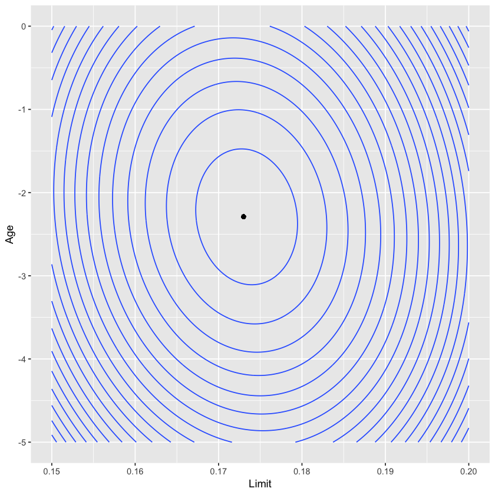

```r
library(ggplot2)
p1 <- ggplot(grid1, aes(Limit, Age, z = density))
p1 + geom_point(x=0.173,y=-2.29) + geom_contour(bins = 20)
```

|  | Var1 | Var2 | density |
| --- | --- | --- | --- |
| 20504 | 2.105528 | 0.03065327 | 53569.71 |

| Rating | Limit | density |
| --- | --- | --- |
| -1.0000000 | -0.2 | 1076786 |
| -0.9698492 | -0.2 | 1067389 |
| -0.9396985 | -0.2 | 1058036 |
| -0.9095477 | -0.2 | 1048726 |
| -0.8793970 | -0.2 | 1039460 |
| -0.8492462 | -0.2 | 1030237 |

[figure not shown]

```r
Rating_grid <- seq(-1,5,length.out = 200)
Limit_grid <- seq(-0.2,0.25,length.out = 200)
grid2 <- expand.grid(Rating_grid,Limit_grid)
X <- data.matrix(cbind(Credit$Rating,Credit$Limit))
y <- Credit$Balance

grid2$density <- apply(grid2,1,FUN=function(beta) sum((y-X%*%beta-mean(y-X%*%beta))^2)/length(y))
grid2[which.min(grid2$density),]
colnames(grid2) <- c("Rating","Limit","density")
head(grid2)

library(ggplot2)
p2 <- ggplot(grid2, aes(y=Rating, x=Limit, z = density))
p2 + geom_point(x=0.02451,y=2.20167) + geom_contour(bins = 20)
```

0.0286539534227904

0.000564285826323816

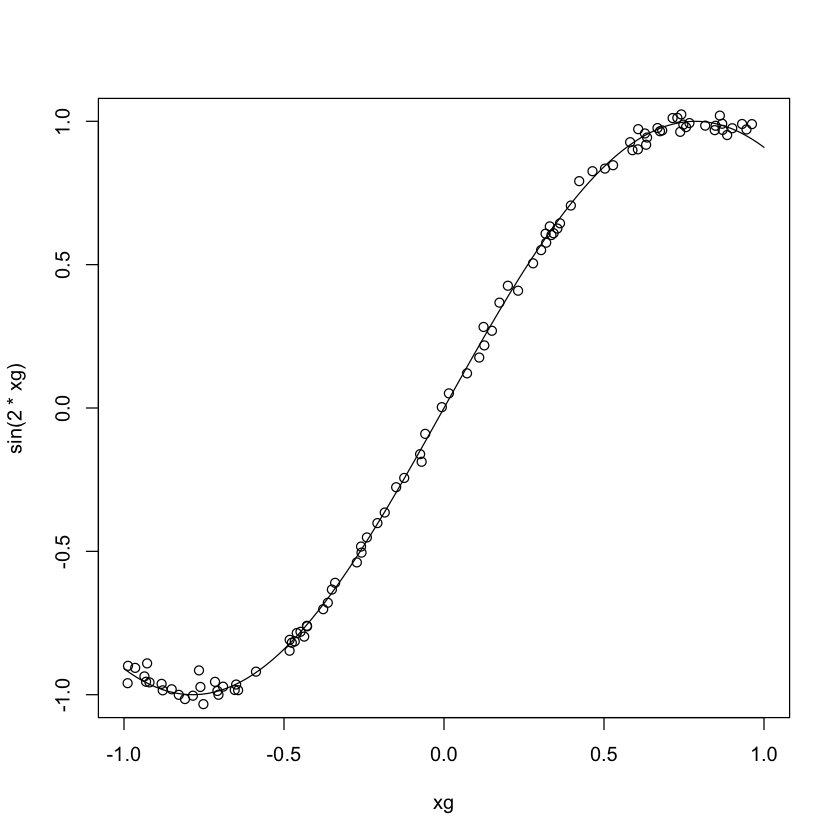

```r
library(FNN)
n <- 100
nt <- 500
sigma <- 0.025
x <- runif(n,-1,1)
xt <- runif(nt,-1,1)
xg <- seq(-1,1,length.out = 100)
y <- sin(2*x) + rnorm(n,0,sigma)
yt <- sin(2*xt) + rnorm(nt,0,sigma)
plot(xg,sin(2*xg),type="l")
points(x,y)

fit_lm <- lm(y~.,data.frame(y=y,x=x))
yh_lm <- predict(fit_lm,data.frame(x=xt))
mean((yt-yh_lm)^2)

fit_knn <- knn.reg(data.frame(y=y,x=x),data.frame(y=yt,x=xt),y = y,k=5)
mean((yt-fit_knn$pred)^2)
```

- KNN outperforms linear model when the ground truth is non-linear.
- what if we add some 'noise'?
- Specifically, we add noisy predictors that are not associated with the response.

| MSE | p |
| --- | --- |
| 0.02602669 | p=1 |
| 0.02618677 | p=2 |
| 0.02620852 | p=3 |
| 0.02622778 | p=4 |
| 0.02898857 | p=10 |
| 0.03336919 | p=20 |

| 1/K | p | MSE |
| --- | --- | --- |
| 1.0000000 | p=1 | 0.0006066571 |
| 0.5000000 | p=1 | 0.0005112288 |
| 0.3333333 | p=1 | 0.0005417893 |
| 0.2500000 | p=1 | 0.0005434514 |
| 0.2000000 | p=1 | 0.0005872388 |
| 0.1666667 | p=1 | 0.0006510612 |

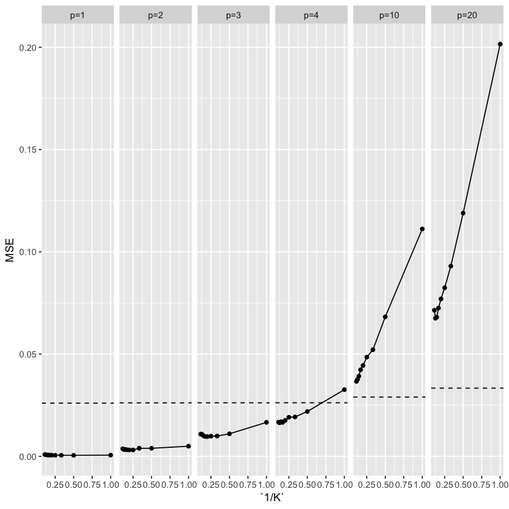

```r
p <- 20
puse <- c(1,2,3,4,10,20)
X <- matrix(runif(n*p,-1,1),n,p)
Xt <- matrix(runif(nt*p,-1,1),nt,p)
y <- sin(2*X[,1]) + rnorm(n,0,sigma)
yt <- sin(2*Xt[,1]) + rnorm(nt,0,sigma)
k <- c(1:9)

MSE_knn <- matrix(0,9,6)
MSE_lm <- rep(0,6)

for(i in 1:length(puse)){
    fit_lm <- lm(y~.,data.frame(y=y,x=X[,1:puse[i]]))
    yh_lm <- predict(fit_lm,data.frame(x=Xt[,1:puse[i]]))
    MSE_lm[i] <- mean((yt-yh_lm)^2)

    for(j in 1:length(k)){
        fit_knn <- knn.reg(data.frame(y=y,x=X[,1:puse[i]]),data.frame(y=yt,x=Xt[,1:puse[i]]),y = y,k=k[j])
        MSE_knn[j,i] <- mean((yt-fit_knn$pred)^2)
    }
}

colnames(MSE_knn) <- paste0("p=",puse)
MSE_knn <- data.frame(MSE_knn,invK=1/k,check.names = F)
MSE_lm <- data.frame(MSE=MSE_lm,p=paste0("p=",puse))

library(reshape2)
MSE_knn <- melt(MSE_knn,id.vars ="invK")
colnames(MSE_knn) <- c("1/K","p","MSE")
head(MSE_lm)
head(MSE_knn)

p <- ggplot(MSE_knn,aes(x=`1/K`,y=MSE)) + geom_point() + geom_line() + facet_grid(~p)

p+geom_hline(data = MSE_lm, aes(yintercept = MSE),linetype = "dashed")
```

- When p = 1-3, KNN outperforms linear regression.
- But for p = 4 the results are mixed.
- For p ≥ 5 linear regression is superior to KNN.
- This decrease in performance as the dimension increases is a common problem for KNN, and results from the fact that in higher dimensions there is effectively a reduction in sample size.
- when p = 1, n=100 provides enough information to accurately estimate f(X).
- However, spreading 100 observations over p = 20 dimensions results in a phenomenon in which a given observation has no nearby neighbors—this is the so-called **curse of dimensionality**.

# Chapter 4 Lab: Logistic Regression, LDA, QDA, and KNN

## The Stock Market Data

| Year | Lag1 | Lag2 | Lag3 | Lag4 | Lag5 | Volume | Today | Direction |
| --- | --- | --- | --- | --- | --- | --- | --- | --- |
| 2001 | 0.381 | -0.192 | -2.624 | -1.055 | 5.010 | 1.1913 | 0.959 | Up |
| 2001 | 0.959 | 0.381 | -0.192 | -2.624 | -1.055 | 1.2965 | 1.032 | Up |
| 2001 | 1.032 | 0.959 | 0.381 | -0.192 | -2.624 | 1.4112 | -0.623 | Down |
| 2001 | -0.623 | 1.032 | 0.959 | 0.381 | -0.192 | 1.2760 | 0.614 | Up |
| 2001 | 0.614 | -0.623 | 1.032 | 0.959 | 0.381 | 1.2057 | 0.213 | Up |
| 2001 | 0.213 | 0.614 | -0.623 | 1.032 | 0.959 | 1.3491 | 1.392 | Up |

1. 1250

2. 9

```
      Year           Lag1                Lag2                Lag3
 Min.   :2001   Min.   :-4.922000   Min.   :-4.922000   Min.   :-4.922000
 1st Qu.:2002   1st Qu.:-0.639500   1st Qu.:-0.639500   1st Qu.:-0.640000
 Median :2003   Median : 0.039000   Median : 0.039000   Median : 0.038500
 Mean   :2003   Mean   : 0.003834   Mean   : 0.003919   Mean   : 0.001716
 3rd Qu.:2004   3rd Qu.: 0.596750   3rd Qu.: 0.596750   3rd Qu.: 0.596750
 Max.   :2005   Max.   : 5.733000   Max.   : 5.733000   Max.   : 5.733000
      Lag4                Lag5              Volume           Today
 Min.   :-4.922000   Min.   :-4.92200   Min.   :0.3561   Min.   :-4.922000
 1st Qu.:-0.640000   1st Qu.:-0.64000   1st Qu.:1.2574   1st Qu.:-0.639500
 Median : 0.038500   Median : 0.03850   Median :1.4229   Median : 0.038500
 Mean   : 0.001636   Mean   : 0.00561   Mean   :1.4783   Mean   : 0.003138
 3rd Qu.: 0.596750   3rd Qu.: 0.59700   3rd Qu.:1.6417   3rd Qu.: 0.596750
 Max.   : 5.733000   Max.   : 5.73300   Max.   :3.1525   Max.   : 5.733000
 Direction
 Down:602
 Up  :648
```

|  | Year | Lag1 | Lag2 | Lag3 | Lag4 | Lag5 | Volume | Today |
| --- | --- | --- | --- | --- | --- | --- | --- | --- |
| Year | 1.00000000 | 0.029699649 | 0.030596422 | 0.033194581 | 0.035688718 | 0.029787995 | 0.53900647 | 0.030095229 |
| Lag1 | 0.02969965 | 1.000000000 | -0.026294328 | -0.010803402 | -0.002985911 | -0.005674606 | 0.04090991 | -0.026155045 |
| Lag2 | 0.03059642 | -0.026294328 | 1.000000000 | -0.025896670 | -0.010853533 | -0.003557949 | -0.04338321 | -0.010250033 |
| Lag3 | 0.03319458 | -0.010803402 | -0.025896670 | 1.000000000 | -0.024051036 | -0.018808338 | -0.04182369 | -0.002447647 |
| Lag4 | 0.03568872 | -0.002985911 | -0.010853533 | -0.024051036 | 1.000000000 | -0.027083641 | -0.04841425 | -0.006899527 |
| Lag5 | 0.02978799 | -0.005674606 | -0.003557949 | -0.018808338 | -0.027083641 | 1.000000000 | -0.02200231 | -0.034860083 |
| Volume | 0.53900647 | 0.040909908 | -0.043383215 | -0.041823686 | -0.048414246 | -0.022002315 | 1.00000000 | 0.014591823 |
| Today | 0.03009523 | -0.026155045 | -0.010250033 | -0.002447647 | -0.006899527 | -0.034860083 | 0.01459182 | 1.000000000 |

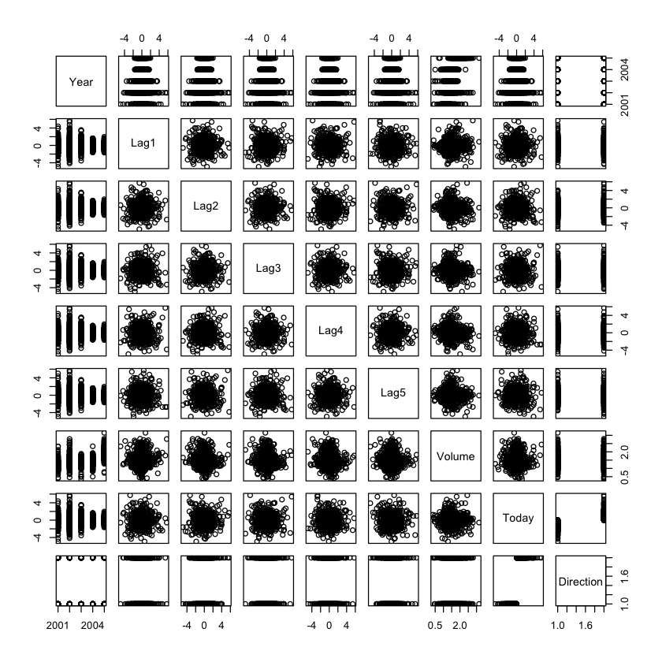

```r
library(ISLR)
head(Smarket)
dim(Smarket)
summary(Smarket)
pairs(Smarket)
cor(Smarket[,-9])
```

## Logistic regression

- we will fit a logistic regression model in order to predict Direction using `Lag1` through `Lag5` and `Volume`.
- The `glm()` function fits *generalized linear models*, a class of models that includes *logistic regression*.
- The syntax of `glm()` function is similar to that of `lm()`, except that we must pass in linear model the argument `family=binomial` in order to tell R to run a logistic regression rather than some other type of generalized linear model.

```r
# Logistic Regression

glm.fits=glm(Direction~Lag1+Lag2+Lag3+Lag4+Lag5+Volume,data=Smarket,family=binomial)
summary(glm.fits)
coef(glm.fits)
summary(glm.fits)$coef
```

```
Call:
glm(formula = Direction ~ Lag1 + Lag2 + Lag3 + Lag4 + Lag5 +
    Volume, family = binomial, data = Smarket)

Deviance Residuals:
   Min      1Q  Median      3Q     Max
-1.446  -1.203   1.065   1.145   1.326

Coefficients:
             Estimate Std. Error z value Pr(>|z|)
(Intercept) -0.126000   0.240736  -0.523    0.601
Lag1        -0.073074   0.050167  -1.457    0.145
Lag2        -0.042301   0.050086  -0.845    0.398
Lag3         0.011085   0.049939   0.222    0.824
Lag4         0.009359   0.049974   0.187    0.851
Lag5         0.010313   0.049511   0.208    0.835
Volume       0.135441   0.158360   0.855    0.392

(Dispersion parameter for binomial family taken to be 1)

    Null deviance: 1731.2  on 1249  degrees of freedom
Residual deviance: 1727.6  on 1243  degrees of freedom
AIC: 1741.6

Number of Fisher Scoring iterations: 3
```

**(Intercept)**

-0.126000256559266

**Lag1**

-0.0730737458900261

**Lag2**

-0.0423013440073083

**Lag3**

0.0110851083796762

**Lag4**

0.0093589383702787

**Lag5**

0.0103130684758179

**Volume**

0.13544065885916

|  | Estimate | Std. Error | z value | Pr(>\|z\|) |
| --- | --- | --- | --- | --- |
| (Intercept) | -0.126000257 | 0.24073574 | -0.5233966 | 0.6006983 |
| Lag1 | -0.073073746 | 0.05016739 | -1.4565986 | 0.1452272 |
| Lag2 | -0.042301344 | 0.05008605 | -0.8445733 | 0.3983491 |
| Lag3 | 0.011085108 | 0.04993854 | 0.2219750 | 0.8243333 |
| Lag4 | 0.009358938 | 0.04997413 | 0.1872757 | 0.8514445 |
| Lag5 | 0.010313068 | 0.04951146 | 0.2082966 | 0.8349974 |
| Volume | 0.135440659 | 0.15835970 | 0.8552723 | 0.3924004 |

- The `predict()` function can be used to predict the probability that the market will go up, given values of the predictors.
- By default it returns the logit values, e.g., $log(\frac{P(Y = 1|X)}{P(Y = 0|X)})$
- The type="response" option tells R to output probabilities of the form P(Y = 1|X).

```r
glm.probs=predict(glm.fits)
glm.probs[1:10]
glm.probs=predict(glm.fits,type="response")
glm.probs[1:10]
log(glm.probs[1:10]/(1-glm.probs[1:10]))
```

**1**

0.0283384298998879

**2**

-0.0741624590581816

**3**

-0.075480474993718

**4**

0.060908246126795

**5**

0.0431313360015101

**6**

0.0278276377584627

**7**

-0.0293986204527711

**8**

0.0369208263019545

**9**

0.0704832696302417

**10**

-0.0446563005125991

**1**

0.507084133395402

**2**

0.481467878454591

**3**

0.481138835214201

**4**

0.515222355813022

**5**

0.510781162691538

**6**

0.506956460534911

**7**

0.492650874187038

**8**

0.509229158207377

**9**

0.517613526170958

**10**

0.488837779771376

**1**

0.0283384298998878

**2**

-0.0741624590581817

**3**

-0.0754804749937181

**4**

0.060908246126795

**5**

0.0431313360015097

**6**

0.0278276377584628

**7**

-0.029398620452771

**8**

0.036920826301954

**9**

0.0704832696302414

**10**

-0.0446563005125991

- We can check the prediction performance by producing a table and compute the accuracy

```r
attach(Smarket)
contrasts(Direction)
glm.pred=rep("Down",1250)
glm.pred[glm.probs>.5]="Up"
table(glm.pred,Direction)
(507+145)/1250
mean(glm.pred==Direction)
```

|  | Up |
| --- | --- |
| Down | 0 |
| Up | 1 |

```
        Direction
glm.pred Down  Up
    Down  145 141
    Up    457 507
```

0.5216

0.5216

- At first glance, it looks a little bit better than random guess. But this result is evaluated on the training set.
- Intuitively, the testing result will be worse due to the overfit rpoblem.
- Let's fit the model using two independent datasets: fit the model using observations from 2001-2004; test the results using a held-out data of obserations from 2005.

```r
train=(Year<2005)
Smarket.2005=Smarket[!train,]
dim(Smarket.2005)
Direction.2005=Direction[!train]
```

1. 252

2. 9

```r
# fit the model using training set
glm.fits=glm(Direction~Lag1+Lag2+Lag3+Lag4+Lag5+Volume,data=Smarket,family=binomial,subset=train)
# predict the probabilities based on the test set
glm.probs=predict(glm.fits,Smarket.2005,type="response")
# Make prediction based on the probabilities
glm.pred=rep("Down",252)
glm.pred[glm.probs>.5]="Up"
# check accuracy
table(glm.pred,Direction.2005)
cat("the accuracy is now ",mean(glm.pred==Direction.2005),"\n")
cat("the error rate is now ",mean(glm.pred!=Direction.2005),"\n")
```

```
        Direction.2005
glm.pred Down Up
    Down   77 97
    Up     34 44
```

```
the accuracy is now  0.4801587
the error rate is now  0.5198413
```

- Now, the test error rate is 52 %, which is worse than random guessing!
- Of course this result is not all that surprising, given that one would not generally expect to be able to use previous days’ returns to predict future market performance.
- We recall that the logistic regression model had very underwhelming pvalues associated with all of the predictors, and that the smallest p-value, though not very small, corresponded to `Lag1`.
- Perhaps by removing the variables that appear not to be helpful in predicting `Direction`, we can obtain a more effective model.
- Below we have refit the logistic regression using just `Lag1` and `Lag2`, which seemed to have the highest predictive power in the original logistic regression model.

```r
glm.fits=glm(Direction~Lag1+Lag2,data=Smarket,family=binomial,subset=train)
glm.probs=predict(glm.fits,Smarket.2005,type="response")
glm.pred=rep("Down",252)
glm.pred[glm.probs>.5]="Up"
table(glm.pred,Direction.2005)
mean(glm.pred==Direction.2005)
```

```
        Direction.2005
glm.pred Down  Up
    Down   35  35
    Up     76 106
```

0.55952380952381

## LDA

In R, we fit an LDA modelusing the `lda()` function, which is part of the `MASS` library.

- Notice that the syntax for the `lda()` function is identical to that of `lm()`, and to that of `glm()` except for the absence of the `family` option.

```
Call:
lda(Direction ~ Lag1 + Lag2, data = Smarket, subset = train)

Prior probabilities of groups:
    Down       Up
0.491984 0.508016

Group means:
            Lag1        Lag2
Down  0.04279022  0.03389409
Up   -0.03954635 -0.03132544

Coefficients of linear discriminants:
            LD1
Lag1 -0.6420190
Lag2 -0.5135293
```

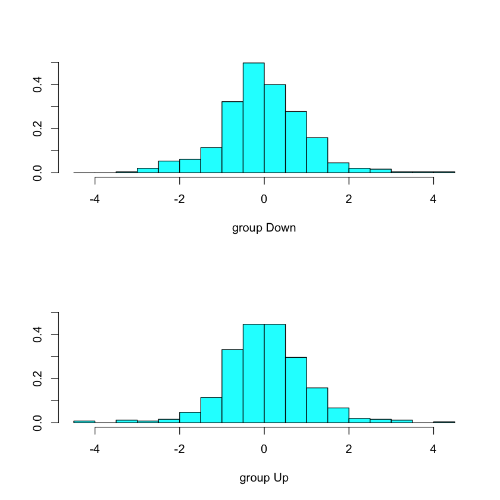

```r
# Linear Discriminant Analysis

library(MASS)
lda.fit=lda(Direction~Lag1+Lag2,data=Smarket,subset=train)
lda.fit
plot(lda.fit)
```

- The LDA output indicates that $\pi_1 = 0.492$ and $\pi_2 = 0.508$; in other words, 49.2% of the training observations correspond to days during which the market went down.
- It also provides the group means; these are the average of each predictor within each class, and are used by LDA as estimate of $\mu_k$.
- These suggest that there is a tendency for the previous 2 days returns to be negative on days when the market increases, and a tendency for the previous days’ returns to be positive on days when the market declines.

```r
lda.pred=predict(lda.fit, Smarket.2005)
names(lda.pred)
```

1. 'class'

2. 'posterior'

3. 'x'

- The `predict()` function returns a list with three elements. We focus on the first two
- The first element, `class`, contains LDA’s predictions about the movement of the market.
- The second element, `posterior`, is a matrix whose kth column contains theposterior probability that the corresponding observation belongs to the kthclass.

```r
head(lda.pred$posterior)
head(lda.pred$class) # this prediction uses 0.5 as the posterior threshold
```

|  | Down | Up |
| --- | --- | --- |
| 999 | 0.4901792 | 0.5098208 |
| 1000 | 0.4792185 | 0.5207815 |
| 1001 | 0.4668185 | 0.5331815 |
| 1002 | 0.4740011 | 0.5259989 |
| 1003 | 0.4927877 | 0.5072123 |
| 1004 | 0.4938562 | 0.5061438 |

1. Up

2. Up

3. Up

4. Up

5. Up

6. Up

**Levels**:**

1. 'Down'

2. 'Up'

```r
lda.class=lda.pred$class
table(lda.class,Direction.2005)
cat("The prediction accuracy is",mean(lda.class==Direction.2005),"\n")
```

```
         Direction.2005
lda.class Down  Up
     Down   35  35
     Up     76 106
```

```
The prediction accuracy is 0.5595238
```

- The prediction performance is the same as logistic regression.

## QDA

We will now fit a QDA model to the Smarket data. QDA is implemented in R using the `qda()` function, which is also part of the `MASS` library. The syntax is identical to that of `lda()`.

```r
# Quadratic Discriminant Analysis

qda.fit=qda(Direction~Lag1+Lag2,data=Smarket,subset=train)
qda.fit
```

```
Call:
qda(Direction ~ Lag1 + Lag2, data = Smarket, subset = train)

Prior probabilities of groups:
    Down       Up
0.491984 0.508016

Group means:
            Lag1        Lag2
Down  0.04279022  0.03389409
Up   -0.03954635 -0.03132544
```

```r
qda.class=predict(qda.fit,Smarket.2005)$class
table(qda.class,Direction.2005)
cat("The prediction accuracy is now ",mean(qda.class==Direction.2005),"!\n",sep="")
```

```
         Direction.2005
qda.class Down  Up
     Down   30  20
     Up     81 121
```

```
The prediction accuracy is now 0.5992063!
```

Interestingly, the QDA predictions are accurate almost 60% of the time, even though the 2005 data was not used to fit the model. This level of accuracy is quite impressive for stock market data, which is known to be quite hard to model accurately.

- This suggests that the quadratic form assumed by QDA may capture the true relationship more accurately than the linearforms assumed by LDA and logistic regression.
- However, it would be better to evaluate this method’s performance on a larger test set before betting that this approach will consistently beat the market!

```r
# K-Nearest Neighbors
library(class)

train.X=cbind(Lag1,Lag2)[train,]
test.X=cbind(Lag1,Lag2)[!train,]
train.Direction=Direction[train]
set.seed(1) # set seed for tied values
knn.pred=knn(train.X,test.X,train.Direction,k=1)
table(knn.pred,Direction.2005)
cat("The prediction accuracy is",mean(knn.pred==Direction.2005),"\n")
```

```
        Direction.2005
knn.pred Down Up
    Down   43 58
    Up     68 83
```

```
The prediction accuracy is 0.5
```

```r
# Increase k to 3
knn.pred=knn(train.X,test.X,train.Direction,k=3)
table(knn.pred,Direction.2005)
cat("The prediction accuracy is",mean(knn.pred==Direction.2005),"\n")
```

```
        Direction.2005
knn.pred Down Up
    Down   48 54
    Up     63 87
```

```
The prediction accuracy is 0.5357143
```

# Exercise

- Try to apply the KNN approach to the Caravan data set, which is part of the `ISLR` library. This data set includes 85 predictors that measure demographic characteristics for 5,822 individuals.
- Use `Purchase` as response

```r
# An Application to Caravan Insurance Data
dim(Caravan)
attach(Caravan)
head(Caravan)
```

1. 5822

2. 86

| MOSTYPE | MAANTHUI | MGEMOMV | MGEMLEEF | MOSHOOFD | MGODRK | MGODPR | MGODOV | MGODGE | MRELGE | ... | APERSONG | AGEZONG | AWAOREG | ABRAND | AZEILPL | APLEZIER | AFIETS | AINBOED | ABYSTAND | Purchase |
| --- | --- | --- | --- | --- | --- | --- | --- | --- | --- | --- | --- | --- | --- | --- | --- | --- | --- | --- | --- | --- |
| 33 | 1 | 3 | 2 | 8 | 0 | 5 | 1 | 3 | 7 | ... | 0 | 0 | 0 | 1 | 0 | 0 | 0 | 0 | 0 | No |
| 37 | 1 | 2 | 2 | 8 | 1 | 4 | 1 | 4 | 6 | ... | 0 | 0 | 0 | 1 | 0 | 0 | 0 | 0 | 0 | No |
| 37 | 1 | 2 | 2 | 8 | 0 | 4 | 2 | 4 | 3 | ... | 0 | 0 | 0 | 1 | 0 | 0 | 0 | 0 | 0 | No |
| 9 | 1 | 3 | 3 | 3 | 2 | 3 | 2 | 4 | 5 | ... | 0 | 0 | 0 | 1 | 0 | 0 | 0 | 0 | 0 | No |
| 40 | 1 | 4 | 2 | 10 | 1 | 4 | 1 | 4 | 7 | ... | 0 | 0 | 0 | 1 | 0 | 0 | 0 | 0 | 0 | No |
| 23 | 1 | 2 | 1 | 5 | 0 | 5 | 0 | 5 | 0 | ... | 0 | 0 | 0 | 0 | 0 | 0 | 0 | 0 | 0 | No |

```r
standardized.X=scale(Caravan[,-86])
var(Caravan[,1])
var(Caravan[,2])
var(standardized.X[,1])
var(standardized.X[,2])
test=1:1000
train.X=standardized.X[-test,]
test.X=standardized.X[test,]
train.Y=Purchase[-test]
test.Y=Purchase[test]
set.seed(1)
knn.pred=knn(train.X,test.X,train.Y,k=1)
mean(test.Y!=knn.pred)
mean(test.Y!="No")
table(knn.pred,test.Y)
9/(68+9)
knn.pred=knn(train.X,test.X,train.Y,k=3)
table(knn.pred,test.Y)
5/26
knn.pred=knn(train.X,test.X,train.Y,k=5)
table(knn.pred,test.Y)
4/15
glm.fits=glm(Purchase~.,data=Caravan,family=binomial,subset=-test)
glm.probs=predict(glm.fits,Caravan[test,],type="response")
glm.pred=rep("No",1000)
glm.pred[glm.probs>.5]="Yes"
table(glm.pred,test.Y)
glm.pred=rep("No",1000)
glm.pred[glm.probs>.25]="Yes"
table(glm.pred,test.Y)
11/(22+11)
```

[output not shown]